# Homework 7

Liu Huihang

10/22/2019

## Problem 1 (Homework 7.1)

Consider Bart Simpson density
$$\begin{equation}
f(x)=\frac{1}{2} \phi(x ; 0,1)+\frac{1}{10} \sum_{j=0}^{4} \phi(x ;(j / 2)-1,1 / 10)
\end{equation}$$
where $\phi(x ;\mu, \sigma)$ denotes a Normal density with mean $\mu$ and standard deviation $\sigma$.

Generate $1000$ sample from Bart Simpson distribution, estimate its density by histogram and compare different interval segmentation method. Estimate density use naive density estimator with image and compare the effect of different bandwidth $h$.

## Answer 1

### Data Preparation

We generate samples from multinomial distribution with proportion $0.5, 0.1, 0.1, 0.1, 0.1, 0.1$, whose values correspond to different distributions within the Bart Simpson distribution respectively.

```r
set.seed(111)
pro <- c(0.5, 0.1, 0.1, 0.1, 0.1, 0.1)
multi <- sample(1:6, 1000, replace = T, prob=pro)
mu <- c(0, seq(-1,1,0.5))
sigma <- c(1, rep(sqrt(1/10), 5))
x <- NULL
for (ii in 1:6) {
  com_txt <- paste("com", ii, " <- rnorm(length(which(multi==", ii, ")), mean=", mu[ii], ", sd=", sigma[ii], ")",sep="")
  eval(parse(text=com_txt))
  com_txt <- paste("x <- c(x, com", ii, ")", sep="")
  eval(parse(text=com_txt))
}
```

### Histogram

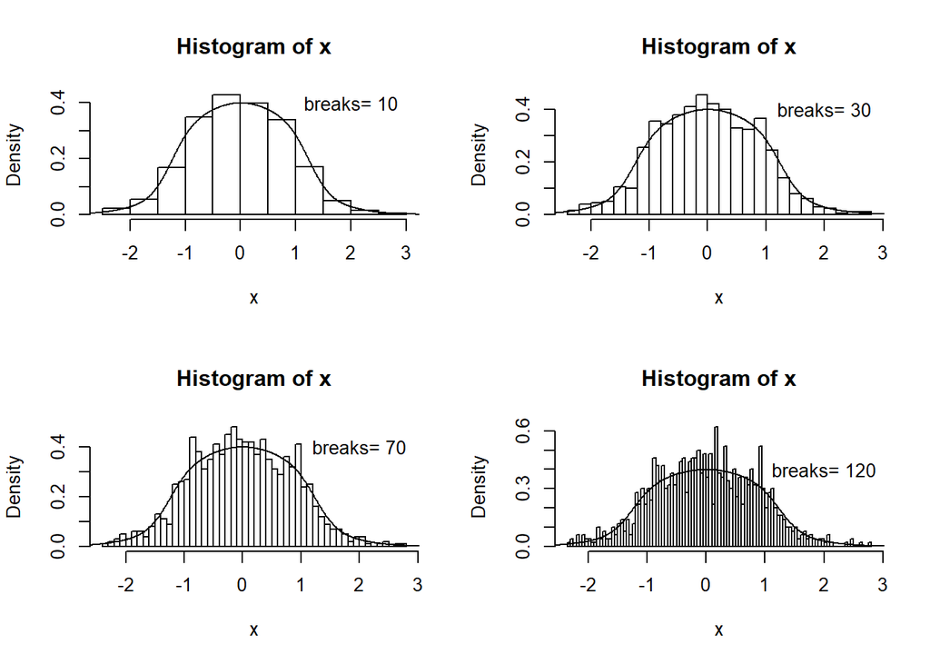

```r
y <- seq(-4, 4, 0.01)
z <- rep(0, 801)
for (ii in 1:6) {
  z <- z + pro[ii] * dnorm(y, mean=mu[ii], sd=sigma[ii])
}
par(mfrow=c(2,2))
for (breaks in c(10, 30, 70, 120)) {
  hist(x, breaks=breaks, freq=FALSE)
  lines(y, z)
  text(x=2, y=0.4, paste("breaks=", breaks))
}
```

We find that the histograms underfit the true density function when breaks is small, while overfit the true density function with large breaks. The bar figure fit tight with moderate breaks only.

### Naive Density Estimator

The naive density estimate is
$$\begin{equation}
\hat{f}_h(x) = \frac{1}{hn} \sum_{i=1}^n K\left( \frac{X_i -x}{h} \right)
\end{equation}$$
where $K(x)=I(-1<x\le1)/2$.

Let’s try $h=0.05, 0.4, 1, 2$ and compare the estimated funciton with true funtion.

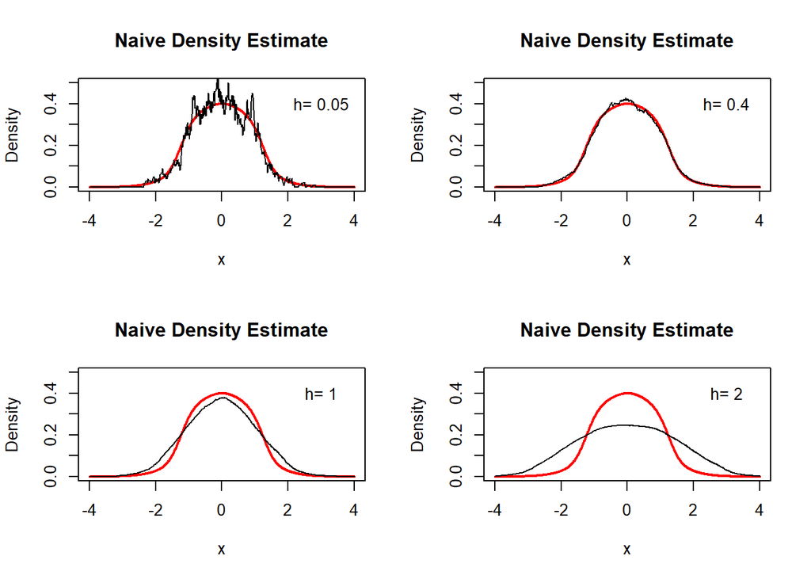

```r
naive <- function(t, h){
  # h is parameter
  # t is variable
  fhx <- 0
  for (xx in x) {
    if (abs(xx - t)/h < 1)
      fhx <- fhx + 1
  }
  fhx / (2 * h * length(x))
}
par(mfrow=c(2,2))
for (h in c(0.05, 0.4, 1, 2)) {
  fh <- unlist(lapply(X=y, FUN=naive, h))
  plot(y, z, "l", lwd=2, col="red", xlab="x", ylab="Density", xlim=c(-4,4), ylim=c(0,0.5))
  lines(y, fh)
  text(x=3, y=0.4, paste("h=",h), )
  title("Naive Density Estimate")
}
```

## Answer 2

### Data Preparation

We generate samples from binnomial distribution with proportion $0.3, 0.7$, whose values correspond to different distributions within the Bart Simpson distribution respectively.

```r
library(kedd)
set.seed(111)
pro <- c(0.3, 0.7)
multi <- sample(1:2, 100, replace = T, prob=pro)
mu <- c(0, 1)
sigma <- c(1, 0.3)
x <- NULL
for (ii in 1:2) {
  com_txt <- paste("com", ii, " <- rnorm(length(which(multi==", ii, ")), mean=", mu[ii], ", sd=", sigma[ii], ")",sep="")
  eval(parse(text=com_txt))
  com_txt <- paste("x <- c(x, com", ii, ")", sep="")
  eval(parse(text=com_txt))
}
```

### Bandwidth selection

We conside $h$ to optimize AMISE, maximum likelihood cross-validation,unbiased cross-calidation, biased cross-calidation, complete cross-calidation, modified cross-calidation,trimmed cross-calidation.

The values of these method is shown following,

```r
amise <- h.amise(x, deriv.order = 0)$h
mlcv <- h.mlcv(x)$h;ucv <- h.ucv(x)$h; bcv <- h.bcv(x)$h;
ccv <- h.ccv(x)$h; mcv <- h.mcv(x)$h; tcv <-  h.tcv(x)$h
h <- c(amise=amise, mlcv=mlcv, ucv=ucv, bcv=bcv, ccv=ccv, mcv=mcv,tcv=tcv)
print(round(h, 4))
```

```
##  amise   mlcv    ucv    bcv    ccv    mcv    tcv
## 0.4880 0.2010 0.2072 0.1936 0.1449 0.2126 0.2708
```

### Draw figure

We can generate KDE by **dkde** function with defalut parameters and draw then in one figure as following.

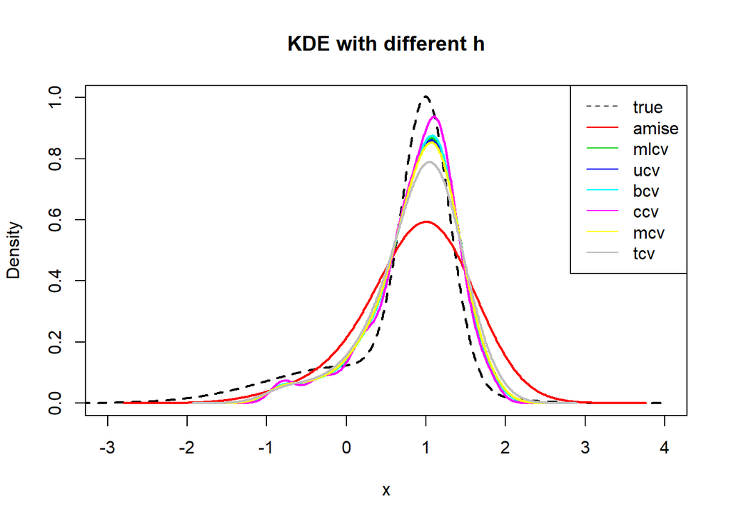

```r
y <- seq(-4, 4, 0.01)
z <- rep(0, length(y))
for (ii in 1:2) {
  z <- z + pro[ii] * dnorm(y, mean=mu[ii], sd=sigma[ii])
}
plot(y, z, "l", lty=2, lwd=2, col=1, xlab="x", ylab="Density", xlim=c(-3,4), ylim=c(0,1))
for (ii in 1:7) {
  lines(dkde(x, h=h[ii]), col=ii+1, lwd=2)
}
legend("topright", legend=c("true","amise","mlcv","ucv","bcv","ccv","mcv","tcv"), col=1:8, lty=c(2, rep(1,7)))
title("KDE with different h")
```